# 1-back Reaction Time Analysis

2025-1-29

## Packages

```r
# import packages
library(lme4) # mixed models
library(dplyr) # dataframe manipulation
library(readr) # reading in the data
library(emmeans) # likelihood ratio testing
```

```r
library(purrr) # for map()
library(lattice) # for xyplot()
library(TAF) # setting up output file directory structure during model fitting
library(moments) # skewness for selecting between additive and multiplicative models of response times
library(filelock)
library(lmerTest)
# If you get an error, you likely need to install the packages using the "install.package('insert-package-name-here')" command
```

## Notebook configurable settings

```r
# name the directories to read data from and write output to
input_version <- 9
output_version <- "n-back"
nback_version <- "1-back"
```

make an overall output directory (model summaries, stats, etc. will all go here)

```r
# setwd("..")
outputdir <- sprintf(
  "%s/../candidate-models/regression-models-%s", getwd(), output_version
)
```

```r
mkdir(outputdir)
```

## Loading Data

```r
# setwd("..")
input_file <- sprintf("%s/../preprocessed-data/full-data-version-%d/nback-full-data.csv", getwd(), input_version)
data <- read.csv(input_file)


# Transforming the session number such that it is treated as a character and not a value
data <- transform(
  data,
  session = as.character(session)
)

head(data)
```

```
##   problem_order participant_id session problem_set start_time_real
## 1             1     REDACTED_0       1           a        REDACTED
## 2             2     REDACTED_0       1           a        REDACTED
## 3             3     REDACTED_0       1           a        REDACTED
## 4             4     REDACTED_0       1           a        REDACTED
## 5             5     REDACTED_0       1           a        REDACTED
## 6             6     REDACTED_0       1           a        REDACTED
##   start_time_experiment end_time_experiment duration shown_letter is_nback
## 1       00:11:27.322784     00:11:28.821960 1.499176            E    False
## 2       00:11:28.822049     00:11:30.182318 1.360269            E     True
## 3       00:11:30.182407     00:11:32.055999 1.873592            A    False
## 4       00:11:32.056101     00:11:33.021651 0.965550            F    False
## 5       00:11:33.021738     00:11:33.995356 0.973618            B    False
## 6       00:11:33.995451     00:11:35.065934 1.070483            C    False
##   expected_key chosen_key correct_answer chose_nothing response.time nback_type
```

[output cut: 27 more lines]

Removing irrelevant data from dataframe

```r
# remove rows that have no values - nothing actually happens here. Everyone saw the stimuli
# data <- data[data$response.time != 0, ]


# Removing the one participants that didn't listen to instructions:
participants_to_remove <- c("REDACTED_20")
data <- subset(data, !(participant_id %in% participants_to_remove))
```

Making sure we are only looking at one type of n-back at a time and only instance of correct response

```r
data <- data[data$correct_answer == "True", ] # only counting the onces they got correct


data <- data[data$nback_type == nback_version, ] # 1-back , 2-back , or 3-back
```

Determining what is the mean response.time

```r
mean_value <- mean((data$response.time))
print(mean_value)
```

```
## [1] 0.5840345
```

Centralizing the response.time so that it is more normally distributed. One-back was not generally normally distributed as seen in the bottom graph so transformation is required

```r
print(skewness(data$response.time))
```

```
## [1] 1.494317
```

```r
print(skewness(sqrt(data$response.time)))
```

```
## [1] 0.9533322
```

```r
print(skewness(log(data$response.time))) # best
```

```
## [1] 0.4259483
```

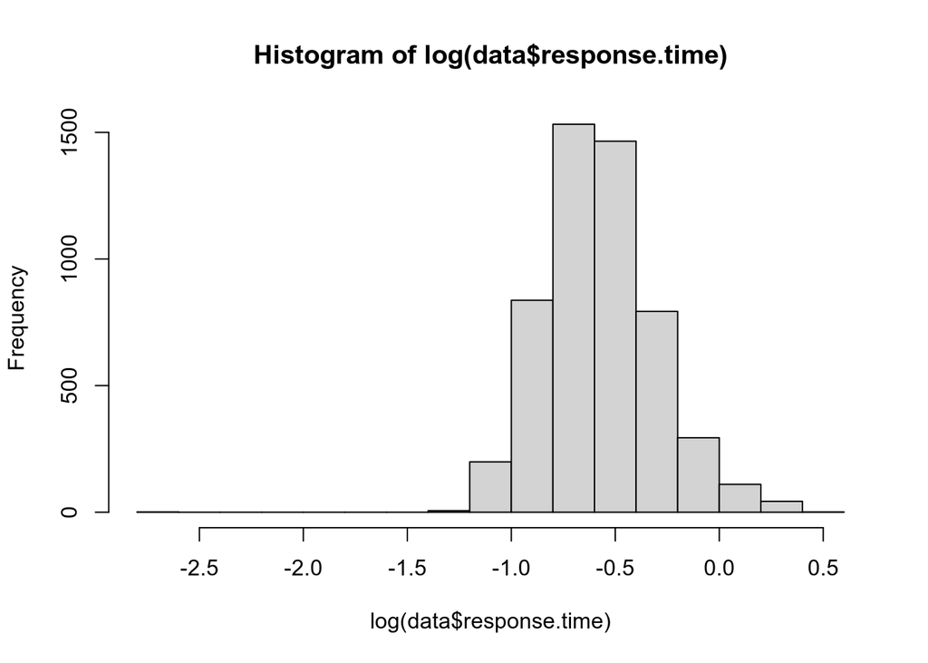

```r
hist(log(data$response.time))
```

Checking number of participants is n=27

```r
id <- unique(data$participant_id)
id # all unique IDs
```

```
##  [1] "REDACTED_0"  "REDACTED_1"  "REDACTED_10" "REDACTED_11" "REDACTED_12"
##  [6] "REDACTED_13" "REDACTED_14" "REDACTED_15" "REDACTED_16" "REDACTED_17"
## [11] "REDACTED_18" "REDACTED_19" "REDACTED_2"  "REDACTED_21" "REDACTED_22"
## [16] "REDACTED_23" "REDACTED_24" "REDACTED_25" "REDACTED_26" "REDACTED_27"
## [21] "REDACTED_3"  "REDACTED_4"  "REDACTED_5"  "REDACTED_6"  "REDACTED_7"
## [26] "REDACTED_8"  "REDACTED_9"
```

```r
length(id) # number of participants
```

```
## [1] 27
```

Checking distribution of of observations per factor load in n-back

```r
count_table <- table(data$TMS_Type, data$nback_type)

# Print the result
print(count_table)
```

```
##
##      1-back
##   CM   2641
##   WM   2640
```

## Select independent variables

1. `participant_id` (person) : random intercept
   - People are drawn from an underlying distribution; we aren’t interested in learning coefficients specific to the members of our sample, but rather in what they tell us about that underlying population. Random effects tell us about the distribution rather than the elements observed.
   - This variable is used to model person-specific attributes, such as a “skill,” translating to overall faster or slower response times, that can be different for each person
2. `shown_letter` (letter presented) : random intercept
   - The underlying distribution of stimuli is a little less clear than that of participants: specifically since stimuli in N-back are just a random fixed set of letters. However, prior work on N-back have found that some letters may be easier to remember than others. We control for that here.
3. `TMS_Type` (TMS treatment condition, i.e. brain region stimulated) : fixed & random intercepts
   - Based on previous literature, we hypothesize that the brain region stimulated may have an effect that is systematic (i.e. very consistent between people, topics, etc.), quantitatively heterogeneous (i.e. directionally consistent, but widely varying in magnitude), or even a qualitatively heterogeneous (i.e. varying in direction, possibly in conjunction with magnitude). Therefore, we assess the goodness of fit for candidate models containing `TMS_Type` as a fixed effect, random effect, both, or neither, in order to test this hypothesis.
4. `session` (chronological numbering of the session, per participant) : fixed intercept
   - This is used to account for learning/training effect, i.e. participants getting better at test-taking under our specific test instrument over the course of the study. For example, they may become more familiar with the question structure, or become better at recalling old material as they do more practice questions. We expect this to be systematic (uniformly decreasing response time), so we model it as a fixed effect.

## Specify candidate predictor structures for mixed model formulas

```r
fixed_effects <- c(
  # no fixed effects
  "",

  # no interactions
  "TMS_Type",
  "session",
  "problem_order",
  "problem_set",
  "pain",
  "physical_symptoms",
  "discomfort",
  "sensations",

  "TMS_Type + session",
  "TMS_Type + problem_order",
  "TMS_Type + problem_set",
  "session + problem_order",
  "session + problem_set",
  "problem_set + problem_order",

  "TMS_Type + pain",
  "TMS_Type + physical_symptoms",
  "TMS_Type + discomfort",
  "TMS_Type + sensations",
  "session + pain",
  "session + physical_symptoms",
  "session + discomfort",
  "session + sensations",
  "problem_order + pain",
  "problem_order + physical_symptoms",
  "problem_order + discomfort",
  "problem_order + sensations",
  "problem_set + pain",
  "problem_set + physical_symptoms",
  "problem_set + discomfort",
  "problem_set + sensations",

  "TMS_Type + session + problem_order + problem_set + pain + physical_symptoms + discomfort + sensations",

  # 2-way interactions
  "TMS_Type * session",
  "TMS_Type * problem_order",
  "TMS_Type * problem_set",
  "session * problem_order",
  "session * problem_set",
  "problem_set * problem_order",

  "TMS_Type * pain",
  "TMS_Type * physical_symptoms",
  "TMS_Type * discomfort",
  "TMS_Type * sensations",
  "session * pain",
  "session * physical_symptoms",
  "session * discomfort",
  "session * sensations",
  "problem_order * pain",
  "problem_order * physical_symptoms",
  "problem_order * discomfort",
  "problem_order * sensations",
  "problem_set * pain",
  "problem_set * physical_symptoms",
  "problem_set * discomfort",
  "problem_set * sensations",

  # 1- and 2-way interactions
  "TMS_Type * session + problem_set + problem_order + pain + physical_symptoms + discomfort + sensations",
  "TMS_Type * problem_set + session + problem_order + pain + physical_symptoms + discomfort + sensations",
  "TMS_Type * problem_order + session + problem_set + pain + physical_symptoms + discomfort + sensations",
  "session * problem_set + TMS_Type + problem_order + pain + physical_symptoms + discomfort + sensations",
  "session * problem_order + TMS_Type + problem_set + pain + physical_symptoms + discomfort + sensations",
  "problem_set * problem_order + TMS_Type + session + pain + physical_symptoms + discomfort + sensations",

  "TMS_Type * pain + session + problem_set + problem_order",
  "TMS_Type * physical_symptoms + session + problem_set + problem_order",
  "TMS_Type * discomfort + session + problem_set + problem_order",
  "TMS_Type * sensations + session + problem_set + problem_order",

  # multiple 2-way interactions
  "TMS_Type * session + problem_set * problem_order + pain + physical_symptoms + discomfort + sensations",
  "TMS_Type * problem_set + session * problem_order + pain + physical_symptoms + discomfort + sensations",
  "TMS_Type * problem_order + session * problem_set + pain + physical_symptoms + discomfort + sensations",

  # 3-way interactions
  "TMS_Type * session * problem_set + problem_order + pain + physical_symptoms + discomfort + sensations",
  "TMS_Type * session * problem_order + problem_set + pain + physical_symptoms + discomfort + sensations",
  "TMS_Type * problem_set * problem_order + session + pain + physical_symptoms + discomfort + sensations",
  "session * problem_set * problem_order + TMS_Type + pain + physical_symptoms + discomfort + sensations"
)
```

```r
random_effects <- c(
  "participant_id",
  "shown_letter",
  # other than adding this term, all is the same as in the programming analyses
  # (it couldn't be included in the programming analyses because there would
  # only be one observation per group)
  "participant_id:shown_letter",
  "participant_id:TMS_Type",
  "shown_letter:TMS_Type"
)
```

In this first cell, we enumerate random effect structures by taking all combinations of the random effects specified in Section 5.

```r
random_effects <- map(random_effects, function(s) sprintf("(1|%s)", s))

random_exprs <- c()
N_random <- length(random_effects)
for (k in 1:N_random) {
  iii <- combn(1:N_random, k, simplify = FALSE)
  for (ii in iii) {
    expr <- paste(random_effects[ii], collapse = " + ")
    random_exprs <- append(random_exprs, expr)
  }
}
```

Now, we combine the response variable, fixed effects, and random effects together to generate our candidate model structures.

```r
loglinear_formulae <- c()
for (fe in fixed_effects) {
  for (re in random_exprs) {
    f <- ""
    if (fe == "") {
      f <- sprintf("log(response.time) ~ %s", re)
    } else {
      f <- sprintf("log(response.time) ~ %s + %s", fe, re)
    }
    loglinear_formulae <- append(loglinear_formulae, f)
  }
}

print(length(loglinear_formulae))
```

```
## [1] 2201
```

### Model fitting (~2 minutes)

Here, we fit all the models. Of note, we use MLE rather than REML for compatibility with the AIC model selection strategy.

We also store BIC (an alternative model selection criterion) in addition to AIC here. The two have different theoretical properties, both of which may be useful. Both describe the log likelihood of a fitted model, with a penalty for model complexity. The penalty in BIC is higher than that for AIC, so optimal-BIC models tend to be smaller (with fewer parameters) than optimal-AIC models. We have done our analysis relying on AIC, but we provide BIC-based model selection here in case the reader is interested.

```r
if (TRUE) {
  # make an output directory for the output of all the candidate linear models
  logtime_outputdir <-
    sprintf("%s/oneback_v9_log_time_model_summaries", outputdir)
  mkdir(logtime_outputdir)

  # make an output file for the AIC and BIC of each model
  metricsfile <- sprintf("%s/metrics.csv", logtime_outputdir)
  file.create(metricsfile)

  sink(
    file = metricsfile,
    append = FALSE,
    type = "output",
    split = FALSE
  )

  cat("formula,AIC,BIC\n")

  sink()

  for (f in loglinear_formulae) {
    # make an output directory for the output of this specific candidate model
    f_outputdir <- sprintf("%s/%s", logtime_outputdir, gsub(" ", "", f, fixed = TRUE))
    mkdir(f_outputdir)

    # make the individual output file
    summaryfile <- sprintf("%s/summary.txt", f_outputdir)

    file.create(summaryfile)

    # print a delimiter for console output
    cat(sprintf("\n---------------------------------------------\n%s\n", f))

    # fit the model
    m <- lmer(f, data = data, REML = FALSE)

    # send the model summary to the summary file
    sink(
      file = summaryfile,
      append = FALSE,
      type = "output",
      split = FALSE
    )

    print(summary(m))

    sink()

    # send the AIC and BIC to the metrics file
    metrics <- sprintf("%s,%f,%f\n", f, AIC(m), BIC(m))

    sink(
      file = metricsfile,
      append = TRUE,
      type = "output",
      split = FALSE
    )

    cat(metrics)

    sink()
  }
}
```

```
##
## ---------------------------------------------
## log(response.time) ~ (1|participant_id)
##
## ---------------------------------------------
## log(response.time) ~ (1|shown_letter)
##
## ---------------------------------------------
## log(response.time) ~ (1|participant_id:shown_letter)
##
## ---------------------------------------------
## log(response.time) ~ (1|participant_id:TMS_Type)
##
## ---------------------------------------------
## log(response.time) ~ (1|shown_letter:TMS_Type)
##
## ---------------------------------------------
## log(response.time) ~ (1|participant_id) + (1|shown_letter)
##
## ---------------------------------------------
## log(response.time) ~ (1|participant_id) + (1|participant_id:shown_letter)
```

```
## boundary (singular) fit: see help('isSingular')
```

```
##
## ---------------------------------------------
## log(response.time) ~ (1|participant_id) + (1|participant_id:TMS_Type)
##
## ---------------------------------------------
## log(response.time) ~ (1|participant_id) + (1|shown_letter:TMS_Type)
##
## ---------------------------------------------
## log(response.time) ~ (1|shown_letter) + (1|participant_id:shown_letter)
```

```
## boundary (singular) fit: see help('isSingular')
```

```
##
## ---------------------------------------------
## log(response.time) ~ (1|shown_letter) + (1|participant_id:TMS_Type)
##
## ---------------------------------------------
## log(response.time) ~ (1|shown_letter) + (1|shown_letter:TMS_Type)
##
## ---------------------------------------------
## log(response.time) ~ (1|participant_id:shown_letter) + (1|participant_id:TMS_Type)
```

```
## boundary (singular) fit: see help('isSingular')
```

```
##
## ---------------------------------------------
## log(response.time) ~ (1|participant_id:shown_letter) + (1|shown_letter:TMS_Type)
##
## ---------------------------------------------
## log(response.time) ~ (1|participant_id:TMS_Type) + (1|shown_letter:TMS_Type)
##
## ---------------------------------------------
## log(response.time) ~ (1|participant_id) + (1|shown_letter) + (1|participant_id:shown_letter)
```

```
## boundary (singular) fit: see help('isSingular')
```

```
##
## ---------------------------------------------
## log(response.time) ~ (1|participant_id) + (1|shown_letter) + (1|participant_id:TMS_Type)
##
## ---------------------------------------------
## log(response.time) ~ (1|participant_id) + (1|shown_letter) + (1|shown_letter:TMS_Type)
```

```
## boundary (singular) fit: see help('isSingular')
```

```
##
## ---------------------------------------------
## log(response.time) ~ (1|participant_id) + (1|participant_id:shown_letter) + (1|participant_id:TMS_Type)
```

```
## boundary (singular) fit: see help('isSingular')
```

```
##
## ---------------------------------------------
## log(response.time) ~ (1|participant_id) + (1|participant_id:shown_letter) + (1|shown_letter:TMS_Type)
```

```
## boundary (singular) fit: see help('isSingular')
```

```
##
## ---------------------------------------------
## log(response.time) ~ (1|participant_id) + (1|participant_id:TMS_Type) + (1|shown_letter:TMS_Type)
##
## ---------------------------------------------
## log(response.time) ~ (1|shown_letter) + (1|participant_id:shown_letter) + (1|participant_id:TMS_Type)
```

```
## boundary (singular) fit: see help('isSingular')
```

```
##
## ---------------------------------------------
## log(response.time) ~ (1|shown_letter) + (1|participant_id:shown_letter) + (1|shown_letter:TMS_Type)
```

```
## boundary (singular) fit: see help('isSingular')
```

```
##
## ---------------------------------------------
## log(response.time) ~ (1|shown_letter) + (1|participant_id:TMS_Type) + (1|shown_letter:TMS_Type)
```

```
## boundary (singular) fit: see help('isSingular')
```

```
##
## ---------------------------------------------
## log(response.time) ~ (1|participant_id:shown_letter) + (1|participant_id:TMS_Type) + (1|shown_letter:TMS_Type)
```

```
## boundary (singular) fit: see help('isSingular')
```

```
##
## ---------------------------------------------
## log(response.time) ~ (1|participant_id) + (1|shown_letter) + (1|participant_id:shown_letter) + (1|participant_id:TMS_Type)
```

```
## boundary (singular) fit: see help('isSingular')
```

```
##
## ---------------------------------------------
## log(response.time) ~ (1|participant_id) + (1|shown_letter) + (1|participant_id:shown_letter) + (1|shown_letter:TMS_Type)
```

```
## boundary (singular) fit: see help('isSingular')
```

```
##
## ---------------------------------------------
## log(response.time) ~ (1|participant_id) + (1|shown_letter) + (1|participant_id:TMS_Type) + (1|shown_letter:TMS_Type)
```

```
## boundary (singular) fit: see help('isSingular')
```

```
##
## ---------------------------------------------
## log(response.time) ~ (1|participant_id) + (1|participant_id:shown_letter) + (1|participant_id:TMS_Type) + (1|shown_letter:TMS_Type)
```

```
## boundary (singular) fit: see help('isSingular')
```

```
##
## ---------------------------------------------
## log(response.time) ~ (1|shown_letter) + (1|participant_id:shown_letter) + (1|participant_id:TMS_Type) + (1|shown_letter:TMS_Type)
```

```
## boundary (singular) fit: see help('isSingular')
```

```
##
## ---------------------------------------------
## log(response.time) ~ (1|participant_id) + (1|shown_letter) + (1|participant_id:shown_letter) + (1|participant_id:TMS_Type) + (1|shown_letter:TMS_Type)
```

```
## boundary (singular) fit: see help('isSingular')
```

```
##
## ---------------------------------------------
## log(response.time) ~ TMS_Type + (1|participant_id)
##
## ---------------------------------------------
## log(response.time) ~ TMS_Type + (1|shown_letter)
##
## ---------------------------------------------
## log(response.time) ~ TMS_Type + (1|participant_id:shown_letter)
##
## ---------------------------------------------
## log(response.time) ~ TMS_Type + (1|participant_id:TMS_Type)
##
## ---------------------------------------------
## log(response.time) ~ TMS_Type + (1|shown_letter:TMS_Type)
```

```
## boundary (singular) fit: see help('isSingular')
```

```
##
## ---------------------------------------------
## log(response.time) ~ TMS_Type + (1|participant_id) + (1|shown_letter)
##
## ---------------------------------------------
## log(response.time) ~ TMS_Type + (1|participant_id) + (1|participant_id:shown_letter)
```

```
## boundary (singular) fit: see help('isSingular')
```

```
##
## ---------------------------------------------
## log(response.time) ~ TMS_Type + (1|participant_id) + (1|participant_id:TMS_Type)
##
## ---------------------------------------------
## log(response.time) ~ TMS_Type + (1|participant_id) + (1|shown_letter:TMS_Type)
```

```
## boundary (singular) fit: see help('isSingular')
```

```
##
## ---------------------------------------------
## log(response.time) ~ TMS_Type + (1|shown_letter) + (1|participant_id:shown_letter)
```

```
## boundary (singular) fit: see help('isSingular')
```

```
##
## ---------------------------------------------
## log(response.time) ~ TMS_Type + (1|shown_letter) + (1|participant_id:TMS_Type)
##
## ---------------------------------------------
## log(response.time) ~ TMS_Type + (1|shown_letter) + (1|shown_letter:TMS_Type)
```

```
## boundary (singular) fit: see help('isSingular')
```

```
##
## ---------------------------------------------
## log(response.time) ~ TMS_Type + (1|participant_id:shown_letter) + (1|participant_id:TMS_Type)
```

```
## boundary (singular) fit: see help('isSingular')
```

```
##
## ---------------------------------------------
## log(response.time) ~ TMS_Type + (1|participant_id:shown_letter) + (1|shown_letter:TMS_Type)
```

```
## boundary (singular) fit: see help('isSingular')
```

```
##
## ---------------------------------------------
## log(response.time) ~ TMS_Type + (1|participant_id:TMS_Type) + (1|shown_letter:TMS_Type)
##
## ---------------------------------------------
## log(response.time) ~ TMS_Type + (1|participant_id) + (1|shown_letter) + (1|participant_id:shown_letter)
```

```
## boundary (singular) fit: see help('isSingular')
```

```
##
## ---------------------------------------------
## log(response.time) ~ TMS_Type + (1|participant_id) + (1|shown_letter) + (1|participant_id:TMS_Type)
##
## ---------------------------------------------
## log(response.time) ~ TMS_Type + (1|participant_id) + (1|shown_letter) + (1|shown_letter:TMS_Type)
```

```
## boundary (singular) fit: see help('isSingular')
```

```
##
## ---------------------------------------------
## log(response.time) ~ TMS_Type + (1|participant_id) + (1|participant_id:shown_letter) + (1|participant_id:TMS_Type)
```

```
## boundary (singular) fit: see help('isSingular')
```

```
##
## ---------------------------------------------
## log(response.time) ~ TMS_Type + (1|participant_id) + (1|participant_id:shown_letter) + (1|shown_letter:TMS_Type)
```

```
## boundary (singular) fit: see help('isSingular')
```

```
##
## ---------------------------------------------
## log(response.time) ~ TMS_Type + (1|participant_id) + (1|participant_id:TMS_Type) + (1|shown_letter:TMS_Type)
##
## ---------------------------------------------
## log(response.time) ~ TMS_Type + (1|shown_letter) + (1|participant_id:shown_letter) + (1|participant_id:TMS_Type)
```

```
## boundary (singular) fit: see help('isSingular')
```

```
##
## ---------------------------------------------
## log(response.time) ~ TMS_Type + (1|shown_letter) + (1|participant_id:shown_letter) + (1|shown_letter:TMS_Type)
```

```
## boundary (singular) fit: see help('isSingular')
```

```
##
## ---------------------------------------------
## log(response.time) ~ TMS_Type + (1|shown_letter) + (1|participant_id:TMS_Type) + (1|shown_letter:TMS_Type)
```

```
## boundary (singular) fit: see help('isSingular')
```

```
##
## ---------------------------------------------
## log(response.time) ~ TMS_Type + (1|participant_id:shown_letter) + (1|participant_id:TMS_Type) + (1|shown_letter:TMS_Type)
```

```
## boundary (singular) fit: see help('isSingular')
```

```
##
## ---------------------------------------------
## log(response.time) ~ TMS_Type + (1|participant_id) + (1|shown_letter) + (1|participant_id:shown_letter) + (1|participant_id:TMS_Type)
```

```
## boundary (singular) fit: see help('isSingular')
```

```
##
## ---------------------------------------------
## log(response.time) ~ TMS_Type + (1|participant_id) + (1|shown_letter) + (1|participant_id:shown_letter) + (1|shown_letter:TMS_Type)
```

```
## boundary (singular) fit: see help('isSingular')
```

```
##
## ---------------------------------------------
## log(response.time) ~ TMS_Type + (1|participant_id) + (1|shown_letter) + (1|participant_id:TMS_Type) + (1|shown_letter:TMS_Type)
```

```
## boundary (singular) fit: see help('isSingular')
```

```
##
## ---------------------------------------------
## log(response.time) ~ TMS_Type + (1|participant_id) + (1|participant_id:shown_letter) + (1|participant_id:TMS_Type) + (1|shown_letter:TMS_Type)
```

```
## boundary (singular) fit: see help('isSingular')
```

```
##
## ---------------------------------------------
## log(response.time) ~ TMS_Type + (1|shown_letter) + (1|participant_id:shown_letter) + (1|participant_id:TMS_Type) + (1|shown_letter:TMS_Type)
```

```
## boundary (singular) fit: see help('isSingular')
```

```
##
## ---------------------------------------------
## log(response.time) ~ TMS_Type + (1|participant_id) + (1|shown_letter) + (1|participant_id:shown_letter) + (1|participant_id:TMS_Type) + (1|shown_letter:TMS_Type)
```

```
## boundary (singular) fit: see help('isSingular')
```

```
##
## ---------------------------------------------
## log(response.time) ~ session + (1|participant_id)
##
## ---------------------------------------------
## log(response.time) ~ session + (1|shown_letter)
##
## ---------------------------------------------
## log(response.time) ~ session + (1|participant_id:shown_letter)
##
## ---------------------------------------------
## log(response.time) ~ session + (1|participant_id:TMS_Type)
##
## ---------------------------------------------
## log(response.time) ~ session + (1|shown_letter:TMS_Type)
##
## ---------------------------------------------
## log(response.time) ~ session + (1|participant_id) + (1|shown_letter)
##
## ---------------------------------------------
## log(response.time) ~ session + (1|participant_id) + (1|participant_id:shown_letter)
```

```
## boundary (singular) fit: see help('isSingular')
```

```
##
## ---------------------------------------------
## log(response.time) ~ session + (1|participant_id) + (1|participant_id:TMS_Type)
##
## ---------------------------------------------
## log(response.time) ~ session + (1|participant_id) + (1|shown_letter:TMS_Type)
##
## ---------------------------------------------
## log(response.time) ~ session + (1|shown_letter) + (1|participant_id:shown_letter)
```

```
## boundary (singular) fit: see help('isSingular')
```

```
##
## ---------------------------------------------
## log(response.time) ~ session + (1|shown_letter) + (1|participant_id:TMS_Type)
##
## ---------------------------------------------
## log(response.time) ~ session + (1|shown_letter) + (1|shown_letter:TMS_Type)
##
## ---------------------------------------------
## log(response.time) ~ session + (1|participant_id:shown_letter) + (1|participant_id:TMS_Type)
```

```
## boundary (singular) fit: see help('isSingular')
```

```
##
## ---------------------------------------------
## log(response.time) ~ session + (1|participant_id:shown_letter) + (1|shown_letter:TMS_Type)
##
## ---------------------------------------------
## log(response.time) ~ session + (1|participant_id:TMS_Type) + (1|shown_letter:TMS_Type)
```

```
##
## ---------------------------------------------
## log(response.time) ~ session + (1|participant_id) + (1|shown_letter) + (1|participant_id:shown_letter)
```

```
## boundary (singular) fit: see help('isSingular')
```

```
##
## ---------------------------------------------
## log(response.time) ~ session + (1|participant_id) + (1|shown_letter) + (1|participant_id:TMS_Type)
##
## ---------------------------------------------
## log(response.time) ~ session + (1|participant_id) + (1|shown_letter) + (1|shown_letter:TMS_Type)
```

```
## boundary (singular) fit: see help('isSingular')
```

```
##
## ---------------------------------------------
## log(response.time) ~ session + (1|participant_id) + (1|participant_id:shown_letter) + (1|participant_id:TMS_Type)
```

```
##
## ---------------------------------------------
## log(response.time) ~ session + (1|participant_id) + (1|participant_id:shown_letter) + (1|shown_letter:TMS_Type)
```

```
## boundary (singular) fit: see help('isSingular')
```

```
##
## ---------------------------------------------
## log(response.time) ~ session + (1|participant_id) + (1|participant_id:TMS_Type) + (1|shown_letter:TMS_Type)
##
## ---------------------------------------------
## log(response.time) ~ session + (1|shown_letter) + (1|participant_id:shown_letter) + (1|participant_id:TMS_Type)
```

```
## boundary (singular) fit: see help('isSingular')
```

```
##
## ---------------------------------------------
## log(response.time) ~ session + (1|shown_letter) + (1|participant_id:shown_letter) + (1|shown_letter:TMS_Type)
```

```
## boundary (singular) fit: see help('isSingular')
```

```
##
## ---------------------------------------------
## log(response.time) ~ session + (1|shown_letter) + (1|participant_id:TMS_Type) + (1|shown_letter:TMS_Type)
```

```
## boundary (singular) fit: see help('isSingular')
```

```
##
## ---------------------------------------------
## log(response.time) ~ session + (1|participant_id:shown_letter) + (1|participant_id:TMS_Type) + (1|shown_letter:TMS_Type)
```

```
## boundary (singular) fit: see help('isSingular')
```

```
##
## ---------------------------------------------
## log(response.time) ~ session + (1|participant_id) + (1|shown_letter) + (1|participant_id:shown_letter) + (1|participant_id:TMS_Type)
```

```
## boundary (singular) fit: see help('isSingular')
```

```
##
## ---------------------------------------------
## log(response.time) ~ session + (1|participant_id) + (1|shown_letter) + (1|participant_id:shown_letter) + (1|shown_letter:TMS_Type)
```

```
## boundary (singular) fit: see help('isSingular')
```

```
##
## ---------------------------------------------
## log(response.time) ~ session + (1|participant_id) + (1|shown_letter) + (1|participant_id:TMS_Type) + (1|shown_letter:TMS_Type)
```

```
## boundary (singular) fit: see help('isSingular')
```

```
##
## ---------------------------------------------
## log(response.time) ~ session + (1|participant_id) + (1|participant_id:shown_letter) + (1|participant_id:TMS_Type) + (1|shown_letter:TMS_Type)
```

```
## boundary (singular) fit: see help('isSingular')
```

```
##
## ---------------------------------------------
## log(response.time) ~ session + (1|shown_letter) + (1|participant_id:shown_letter) + (1|participant_id:TMS_Type) + (1|shown_letter:TMS_Type)
```

```
## boundary (singular) fit: see help('isSingular')
```

```
##
## ---------------------------------------------
## log(response.time) ~ session + (1|participant_id) + (1|shown_letter) + (1|participant_id:shown_letter) + (1|participant_id:TMS_Type) + (1|shown_letter:TMS_Type)
```

```
## boundary (singular) fit: see help('isSingular')
```

```
##
## ---------------------------------------------
## log(response.time) ~ problem_order + (1|participant_id)
##
## ---------------------------------------------
## log(response.time) ~ problem_order + (1|shown_letter)
##
## ---------------------------------------------
## log(response.time) ~ problem_order + (1|participant_id:shown_letter)
##
## ---------------------------------------------
## log(response.time) ~ problem_order + (1|participant_id:TMS_Type)
##
## ---------------------------------------------
## log(response.time) ~ problem_order + (1|shown_letter:TMS_Type)
##
## ---------------------------------------------
## log(response.time) ~ problem_order + (1|participant_id) + (1|shown_letter)
##
## ---------------------------------------------
## log(response.time) ~ problem_order + (1|participant_id) + (1|participant_id:shown_letter)
```

```
## boundary (singular) fit: see help('isSingular')
```

```
##
## ---------------------------------------------
## log(response.time) ~ problem_order + (1|participant_id) + (1|participant_id:TMS_Type)
##
## ---------------------------------------------
## log(response.time) ~ problem_order + (1|participant_id) + (1|shown_letter:TMS_Type)
##
## ---------------------------------------------
## log(response.time) ~ problem_order + (1|shown_letter) + (1|participant_id:shown_letter)
```

```
## boundary (singular) fit: see help('isSingular')
```

```
##
## ---------------------------------------------
## log(response.time) ~ problem_order + (1|shown_letter) + (1|participant_id:TMS_Type)
##
## ---------------------------------------------
## log(response.time) ~ problem_order + (1|shown_letter) + (1|shown_letter:TMS_Type)
##
## ---------------------------------------------
## log(response.time) ~ problem_order + (1|participant_id:shown_letter) + (1|participant_id:TMS_Type)
##
## ---------------------------------------------
## log(response.time) ~ problem_order + (1|participant_id:shown_letter) + (1|shown_letter:TMS_Type)
##
## ---------------------------------------------
## log(response.time) ~ problem_order + (1|participant_id:TMS_Type) + (1|shown_letter:TMS_Type)
##
## ---------------------------------------------
## log(response.time) ~ problem_order + (1|participant_id) + (1|shown_letter) + (1|participant_id:shown_letter)
```

```
## boundary (singular) fit: see help('isSingular')
```

```
##
## ---------------------------------------------
## log(response.time) ~ problem_order + (1|participant_id) + (1|shown_letter) + (1|participant_id:TMS_Type)
##
## ---------------------------------------------
## log(response.time) ~ problem_order + (1|participant_id) + (1|shown_letter) + (1|shown_letter:TMS_Type)
```

```
## boundary (singular) fit: see help('isSingular')
```

```
##
## ---------------------------------------------
## log(response.time) ~ problem_order + (1|participant_id) + (1|participant_id:shown_letter) + (1|participant_id:TMS_Type)
##
## ---------------------------------------------
## log(response.time) ~ problem_order + (1|participant_id) + (1|participant_id:shown_letter) + (1|shown_letter:TMS_Type)
```

```
## boundary (singular) fit: see help('isSingular')
```

```
##
## ---------------------------------------------
## log(response.time) ~ problem_order + (1|participant_id) + (1|participant_id:TMS_Type) + (1|shown_letter:TMS_Type)
##
## ---------------------------------------------
## log(response.time) ~ problem_order + (1|shown_letter) + (1|participant_id:shown_letter) + (1|participant_id:TMS_Type)
```

```
## boundary (singular) fit: see help('isSingular')
```

```
##
## ---------------------------------------------
## log(response.time) ~ problem_order + (1|shown_letter) + (1|participant_id:shown_letter) + (1|shown_letter:TMS_Type)
```

```
## boundary (singular) fit: see help('isSingular')
```

```
##
## ---------------------------------------------
## log(response.time) ~ problem_order + (1|shown_letter) + (1|participant_id:TMS_Type) + (1|shown_letter:TMS_Type)
```

```
## boundary (singular) fit: see help('isSingular')
```

```
##
## ---------------------------------------------
## log(response.time) ~ problem_order + (1|participant_id:shown_letter) + (1|participant_id:TMS_Type) + (1|shown_letter:TMS_Type)
##
## ---------------------------------------------
## log(response.time) ~ problem_order + (1|participant_id) + (1|shown_letter) + (1|participant_id:shown_letter) + (1|participant_id:TMS_Type)
```

```
##
## ---------------------------------------------
## log(response.time) ~ problem_order + (1|participant_id) + (1|shown_letter) + (1|participant_id:shown_letter) + (1|shown_letter:TMS_Type)
```

```
## boundary (singular) fit: see help('isSingular')
```

```
##
## ---------------------------------------------
## log(response.time) ~ problem_order + (1|participant_id) + (1|shown_letter) + (1|participant_id:TMS_Type) + (1|shown_letter:TMS_Type)
```

```
## boundary (singular) fit: see help('isSingular')
```

```
##
## ---------------------------------------------
## log(response.time) ~ problem_order + (1|participant_id) + (1|participant_id:shown_letter) + (1|participant_id:TMS_Type) + (1|shown_letter:TMS_Type)
```

```
## boundary (singular) fit: see help('isSingular')
```

```
##
## ---------------------------------------------
## log(response.time) ~ problem_order + (1|shown_letter) + (1|participant_id:shown_letter) + (1|participant_id:TMS_Type) + (1|shown_letter:TMS_Type)
```

```
## boundary (singular) fit: see help('isSingular')
```

```
##
## ---------------------------------------------
## log(response.time) ~ problem_order + (1|participant_id) + (1|shown_letter) + (1|participant_id:shown_letter) + (1|participant_id:TMS_Type) + (1|shown_letter:TMS_Type)
```

```
## boundary (singular) fit: see help('isSingular')
```

```
##
## ---------------------------------------------
## log(response.time) ~ problem_set + (1|participant_id)
##
## ---------------------------------------------
## log(response.time) ~ problem_set + (1|shown_letter)
##
## ---------------------------------------------
## log(response.time) ~ problem_set + (1|participant_id:shown_letter)
##
## ---------------------------------------------
## log(response.time) ~ problem_set + (1|participant_id:TMS_Type)
##
## ---------------------------------------------
## log(response.time) ~ problem_set + (1|shown_letter:TMS_Type)
##
## ---------------------------------------------
## log(response.time) ~ problem_set + (1|participant_id) + (1|shown_letter)
##
## ---------------------------------------------
## log(response.time) ~ problem_set + (1|participant_id) + (1|participant_id:shown_letter)
##
## ---------------------------------------------
## log(response.time) ~ problem_set + (1|participant_id) + (1|participant_id:TMS_Type)
##
## ---------------------------------------------
## log(response.time) ~ problem_set + (1|participant_id) + (1|shown_letter:TMS_Type)
##
## ---------------------------------------------
## log(response.time) ~ problem_set + (1|shown_letter) + (1|participant_id:shown_letter)
```

```
## boundary (singular) fit: see help('isSingular')
```

```
##
## ---------------------------------------------
## log(response.time) ~ problem_set + (1|shown_letter) + (1|participant_id:TMS_Type)
##
## ---------------------------------------------
## log(response.time) ~ problem_set + (1|shown_letter) + (1|shown_letter:TMS_Type)
```

```
## boundary (singular) fit: see help('isSingular')
```

```
##
## ---------------------------------------------
## log(response.time) ~ problem_set + (1|participant_id:shown_letter) + (1|participant_id:TMS_Type)
```

```
## boundary (singular) fit: see help('isSingular')
```

```
##
## ---------------------------------------------
## log(response.time) ~ problem_set + (1|participant_id:shown_letter) + (1|shown_letter:TMS_Type)
##
## ---------------------------------------------
## log(response.time) ~ problem_set + (1|participant_id:TMS_Type) + (1|shown_letter:TMS_Type)
##
## ---------------------------------------------
## log(response.time) ~ problem_set + (1|participant_id) + (1|shown_letter) + (1|participant_id:shown_letter)
```

```
## boundary (singular) fit: see help('isSingular')
```

```
##
## ---------------------------------------------
## log(response.time) ~ problem_set + (1|participant_id) + (1|shown_letter) + (1|participant_id:TMS_Type)
##
## ---------------------------------------------
## log(response.time) ~ problem_set + (1|participant_id) + (1|shown_letter) + (1|shown_letter:TMS_Type)
##
## ---------------------------------------------
## log(response.time) ~ problem_set + (1|participant_id) + (1|participant_id:shown_letter) + (1|participant_id:TMS_Type)
```

```
## boundary (singular) fit: see help('isSingular')
```

```
##
## ---------------------------------------------
## log(response.time) ~ problem_set + (1|participant_id) + (1|participant_id:shown_letter) + (1|shown_letter:TMS_Type)
```

```
## boundary (singular) fit: see help('isSingular')
```

```
##
## ---------------------------------------------
## log(response.time) ~ problem_set + (1|participant_id) + (1|participant_id:TMS_Type) + (1|shown_letter:TMS_Type)
##
## ---------------------------------------------
## log(response.time) ~ problem_set + (1|shown_letter) + (1|participant_id:shown_letter) + (1|participant_id:TMS_Type)
```

```
## boundary (singular) fit: see help('isSingular')
```

```
##
## ---------------------------------------------
## log(response.time) ~ problem_set + (1|shown_letter) + (1|participant_id:shown_letter) + (1|shown_letter:TMS_Type)
```

```
## boundary (singular) fit: see help('isSingular')
```

```
##
## ---------------------------------------------
## log(response.time) ~ problem_set + (1|shown_letter) + (1|participant_id:TMS_Type) + (1|shown_letter:TMS_Type)
```

```
## boundary (singular) fit: see help('isSingular')
```

```
##
## ---------------------------------------------
## log(response.time) ~ problem_set + (1|participant_id:shown_letter) + (1|participant_id:TMS_Type) + (1|shown_letter:TMS_Type)
```

```
## boundary (singular) fit: see help('isSingular')
```

```
##
## ---------------------------------------------
## log(response.time) ~ problem_set + (1|participant_id) + (1|shown_letter) + (1|participant_id:shown_letter) + (1|participant_id:TMS_Type)
```

```
## boundary (singular) fit: see help('isSingular')
```

```
##
## ---------------------------------------------
## log(response.time) ~ problem_set + (1|participant_id) + (1|shown_letter) + (1|participant_id:shown_letter) + (1|shown_letter:TMS_Type)
```

```
## boundary (singular) fit: see help('isSingular')
```

```
##
## ---------------------------------------------
## log(response.time) ~ problem_set + (1|participant_id) + (1|shown_letter) + (1|participant_id:TMS_Type) + (1|shown_letter:TMS_Type)
```

```
## boundary (singular) fit: see help('isSingular')
```

```
##
## ---------------------------------------------
## log(response.time) ~ problem_set + (1|participant_id) + (1|participant_id:shown_letter) + (1|participant_id:TMS_Type) + (1|shown_letter:TMS_Type)
```

```
## boundary (singular) fit: see help('isSingular')
```

```
##
## ---------------------------------------------
## log(response.time) ~ problem_set + (1|shown_letter) + (1|participant_id:shown_letter) + (1|participant_id:TMS_Type) + (1|shown_letter:TMS_Type)
```

```
## boundary (singular) fit: see help('isSingular')
```

```
##
## ---------------------------------------------
## log(response.time) ~ problem_set + (1|participant_id) + (1|shown_letter) + (1|participant_id:shown_letter) + (1|participant_id:TMS_Type) + (1|shown_letter:TMS_Type)
```

```
## boundary (singular) fit: see help('isSingular')
```

```
##
## ---------------------------------------------
## log(response.time) ~ pain + (1|participant_id)
##
## ---------------------------------------------
## log(response.time) ~ pain + (1|shown_letter)
##
## ---------------------------------------------
## log(response.time) ~ pain + (1|participant_id:shown_letter)
##
## ---------------------------------------------
## log(response.time) ~ pain + (1|participant_id:TMS_Type)
##
## ---------------------------------------------
## log(response.time) ~ pain + (1|shown_letter:TMS_Type)
##
## ---------------------------------------------
## log(response.time) ~ pain + (1|participant_id) + (1|shown_letter)
##
## ---------------------------------------------
## log(response.time) ~ pain + (1|participant_id) + (1|participant_id:shown_letter)
```

```
## boundary (singular) fit: see help('isSingular')
```

```
##
## ---------------------------------------------
## log(response.time) ~ pain + (1|participant_id) + (1|participant_id:TMS_Type)
##
## ---------------------------------------------
## log(response.time) ~ pain + (1|participant_id) + (1|shown_letter:TMS_Type)
```

```
## boundary (singular) fit: see help('isSingular')
```

```
##
## ---------------------------------------------
## log(response.time) ~ pain + (1|shown_letter) + (1|participant_id:shown_letter)
```

```
## boundary (singular) fit: see help('isSingular')
```

```
##
## ---------------------------------------------
## log(response.time) ~ pain + (1|shown_letter) + (1|participant_id:TMS_Type)
##
## ---------------------------------------------
## log(response.time) ~ pain + (1|shown_letter) + (1|shown_letter:TMS_Type)
```

```
## boundary (singular) fit: see help('isSingular')
```

```
##
## ---------------------------------------------
## log(response.time) ~ pain + (1|participant_id:shown_letter) + (1|participant_id:TMS_Type)
```

```
## boundary (singular) fit: see help('isSingular')
```

```
##
## ---------------------------------------------
## log(response.time) ~ pain + (1|participant_id:shown_letter) + (1|shown_letter:TMS_Type)
```

```
## boundary (singular) fit: see help('isSingular')
```

```
##
## ---------------------------------------------
## log(response.time) ~ pain + (1|participant_id:TMS_Type) + (1|shown_letter:TMS_Type)
##
## ---------------------------------------------
## log(response.time) ~ pain + (1|participant_id) + (1|shown_letter) + (1|participant_id:shown_letter)
```

```
## boundary (singular) fit: see help('isSingular')
```

```
##
## ---------------------------------------------
## log(response.time) ~ pain + (1|participant_id) + (1|shown_letter) + (1|participant_id:TMS_Type)
##
## ---------------------------------------------
## log(response.time) ~ pain + (1|participant_id) + (1|shown_letter) + (1|shown_letter:TMS_Type)
```

```
## boundary (singular) fit: see help('isSingular')
```

```
##
## ---------------------------------------------
## log(response.time) ~ pain + (1|participant_id) + (1|participant_id:shown_letter) + (1|participant_id:TMS_Type)
```

```
##
## ---------------------------------------------
## log(response.time) ~ pain + (1|participant_id) + (1|participant_id:shown_letter) + (1|shown_letter:TMS_Type)
```

```
## boundary (singular) fit: see help('isSingular')
```

```
##
## ---------------------------------------------
## log(response.time) ~ pain + (1|participant_id) + (1|participant_id:TMS_Type) + (1|shown_letter:TMS_Type)
##
## ---------------------------------------------
## log(response.time) ~ pain + (1|shown_letter) + (1|participant_id:shown_letter) + (1|participant_id:TMS_Type)
```

```
## boundary (singular) fit: see help('isSingular')
```

```
##
## ---------------------------------------------
## log(response.time) ~ pain + (1|shown_letter) + (1|participant_id:shown_letter) + (1|shown_letter:TMS_Type)
```

```
## boundary (singular) fit: see help('isSingular')
```

```
##
## ---------------------------------------------
## log(response.time) ~ pain + (1|shown_letter) + (1|participant_id:TMS_Type) + (1|shown_letter:TMS_Type)
```

```
## boundary (singular) fit: see help('isSingular')
```

```
##
## ---------------------------------------------
## log(response.time) ~ pain + (1|participant_id:shown_letter) + (1|participant_id:TMS_Type) + (1|shown_letter:TMS_Type)
```

```
## boundary (singular) fit: see help('isSingular')
```

```
##
## ---------------------------------------------
## log(response.time) ~ pain + (1|participant_id) + (1|shown_letter) + (1|participant_id:shown_letter) + (1|participant_id:TMS_Type)
```

```
##
## ---------------------------------------------
## log(response.time) ~ pain + (1|participant_id) + (1|shown_letter) + (1|participant_id:shown_letter) + (1|shown_letter:TMS_Type)
```

```
## boundary (singular) fit: see help('isSingular')
```

```
##
## ---------------------------------------------
## log(response.time) ~ pain + (1|participant_id) + (1|shown_letter) + (1|participant_id:TMS_Type) + (1|shown_letter:TMS_Type)
```

```
## boundary (singular) fit: see help('isSingular')
```

```
##
## ---------------------------------------------
## log(response.time) ~ pain + (1|participant_id) + (1|participant_id:shown_letter) + (1|participant_id:TMS_Type) + (1|shown_letter:TMS_Type)
```

```
## boundary (singular) fit: see help('isSingular')
```

```
##
## ---------------------------------------------
## log(response.time) ~ pain + (1|shown_letter) + (1|participant_id:shown_letter) + (1|participant_id:TMS_Type) + (1|shown_letter:TMS_Type)
```

```
## boundary (singular) fit: see help('isSingular')
```

```
##
## ---------------------------------------------
## log(response.time) ~ pain + (1|participant_id) + (1|shown_letter) + (1|participant_id:shown_letter) + (1|participant_id:TMS_Type) + (1|shown_letter:TMS_Type)
```

```
## boundary (singular) fit: see help('isSingular')
```

```
##
## ---------------------------------------------
## log(response.time) ~ physical_symptoms + (1|participant_id)
##
## ---------------------------------------------
## log(response.time) ~ physical_symptoms + (1|shown_letter)
##
## ---------------------------------------------
## log(response.time) ~ physical_symptoms + (1|participant_id:shown_letter)
##
## ---------------------------------------------
## log(response.time) ~ physical_symptoms + (1|participant_id:TMS_Type)
##
## ---------------------------------------------
## log(response.time) ~ physical_symptoms + (1|shown_letter:TMS_Type)
```

```
## boundary (singular) fit: see help('isSingular')
```

```
##
## ---------------------------------------------
## log(response.time) ~ physical_symptoms + (1|participant_id) + (1|shown_letter)
##
## ---------------------------------------------
## log(response.time) ~ physical_symptoms + (1|participant_id) + (1|participant_id:shown_letter)
```

```
## boundary (singular) fit: see help('isSingular')
```

```
##
## ---------------------------------------------
## log(response.time) ~ physical_symptoms + (1|participant_id) + (1|participant_id:TMS_Type)
##
## ---------------------------------------------
## log(response.time) ~ physical_symptoms + (1|participant_id) + (1|shown_letter:TMS_Type)
```

```
## boundary (singular) fit: see help('isSingular')
```

```
##
## ---------------------------------------------
## log(response.time) ~ physical_symptoms + (1|shown_letter) + (1|participant_id:shown_letter)
```

```
## boundary (singular) fit: see help('isSingular')
```

```
##
## ---------------------------------------------
## log(response.time) ~ physical_symptoms + (1|shown_letter) + (1|participant_id:TMS_Type)
##
## ---------------------------------------------
## log(response.time) ~ physical_symptoms + (1|shown_letter) + (1|shown_letter:TMS_Type)
```

```
## boundary (singular) fit: see help('isSingular')
```

```
##
## ---------------------------------------------
## log(response.time) ~ physical_symptoms + (1|participant_id:shown_letter) + (1|participant_id:TMS_Type)
```

```
## boundary (singular) fit: see help('isSingular')
```

```
##
## ---------------------------------------------
## log(response.time) ~ physical_symptoms + (1|participant_id:shown_letter) + (1|shown_letter:TMS_Type)
```

```
## boundary (singular) fit: see help('isSingular')
```

```
##
## ---------------------------------------------
## log(response.time) ~ physical_symptoms + (1|participant_id:TMS_Type) + (1|shown_letter:TMS_Type)
##
## ---------------------------------------------
## log(response.time) ~ physical_symptoms + (1|participant_id) + (1|shown_letter) + (1|participant_id:shown_letter)
```

```
## boundary (singular) fit: see help('isSingular')
```

```
##
## ---------------------------------------------
## log(response.time) ~ physical_symptoms + (1|participant_id) + (1|shown_letter) + (1|participant_id:TMS_Type)
##
## ---------------------------------------------
## log(response.time) ~ physical_symptoms + (1|participant_id) + (1|shown_letter) + (1|shown_letter:TMS_Type)
```

```
## boundary (singular) fit: see help('isSingular')
```

```
##
## ---------------------------------------------
## log(response.time) ~ physical_symptoms + (1|participant_id) + (1|participant_id:shown_letter) + (1|participant_id:TMS_Type)
```

```
## boundary (singular) fit: see help('isSingular')
```

```
##
## ---------------------------------------------
## log(response.time) ~ physical_symptoms + (1|participant_id) + (1|participant_id:shown_letter) + (1|shown_letter:TMS_Type)
```

```
## boundary (singular) fit: see help('isSingular')
```

```
##
## ---------------------------------------------
## log(response.time) ~ physical_symptoms + (1|participant_id) + (1|participant_id:TMS_Type) + (1|shown_letter:TMS_Type)
##
## ---------------------------------------------
## log(response.time) ~ physical_symptoms + (1|shown_letter) + (1|participant_id:shown_letter) + (1|participant_id:TMS_Type)
```

```
## boundary (singular) fit: see help('isSingular')
```

```
##
## ---------------------------------------------
## log(response.time) ~ physical_symptoms + (1|shown_letter) + (1|participant_id:shown_letter) + (1|shown_letter:TMS_Type)
```

```
## boundary (singular) fit: see help('isSingular')
```

```
##
## ---------------------------------------------
## log(response.time) ~ physical_symptoms + (1|shown_letter) + (1|participant_id:TMS_Type) + (1|shown_letter:TMS_Type)
```

```
## boundary (singular) fit: see help('isSingular')
```

```
##
## ---------------------------------------------
## log(response.time) ~ physical_symptoms + (1|participant_id:shown_letter) + (1|participant_id:TMS_Type) + (1|shown_letter:TMS_Type)
```

```
## boundary (singular) fit: see help('isSingular')
```

```
##
## ---------------------------------------------
## log(response.time) ~ physical_symptoms + (1|participant_id) + (1|shown_letter) + (1|participant_id:shown_letter) + (1|participant_id:TMS_Type)
```

```
##
## ---------------------------------------------
## log(response.time) ~ physical_symptoms + (1|participant_id) + (1|shown_letter) + (1|participant_id:shown_letter) + (1|shown_letter:TMS_Type)
```

```
## boundary (singular) fit: see help('isSingular')
```

```
##
## ---------------------------------------------
## log(response.time) ~ physical_symptoms + (1|participant_id) + (1|shown_letter) + (1|participant_id:TMS_Type) + (1|shown_letter:TMS_Type)
```

```
## boundary (singular) fit: see help('isSingular')
```

```
##
## ---------------------------------------------
## log(response.time) ~ physical_symptoms + (1|participant_id) + (1|participant_id:shown_letter) + (1|participant_id:TMS_Type) + (1|shown_letter:TMS_Type)
##
## ---------------------------------------------
## log(response.time) ~ physical_symptoms + (1|shown_letter) + (1|participant_id:shown_letter) + (1|participant_id:TMS_Type) + (1|shown_letter:TMS_Type)
```

```
## boundary (singular) fit: see help('isSingular')
```

```
##
## ---------------------------------------------
## log(response.time) ~ physical_symptoms + (1|participant_id) + (1|shown_letter) + (1|participant_id:shown_letter) + (1|participant_id:TMS_Type) + (1|shown_letter:TMS_Type)
```

```
## boundary (singular) fit: see help('isSingular')
```

```
##
## ---------------------------------------------
## log(response.time) ~ discomfort + (1|participant_id)
##
## ---------------------------------------------
## log(response.time) ~ discomfort + (1|shown_letter)
##
## ---------------------------------------------
## log(response.time) ~ discomfort + (1|participant_id:shown_letter)
##
## ---------------------------------------------
## log(response.time) ~ discomfort + (1|participant_id:TMS_Type)
##
## ---------------------------------------------
## log(response.time) ~ discomfort + (1|shown_letter:TMS_Type)
##
## ---------------------------------------------
## log(response.time) ~ discomfort + (1|participant_id) + (1|shown_letter)
##
## ---------------------------------------------
## log(response.time) ~ discomfort + (1|participant_id) + (1|participant_id:shown_letter)
```

```
## boundary (singular) fit: see help('isSingular')
```

```
##
## ---------------------------------------------
## log(response.time) ~ discomfort + (1|participant_id) + (1|participant_id:TMS_Type)
##
## ---------------------------------------------
## log(response.time) ~ discomfort + (1|participant_id) + (1|shown_letter:TMS_Type)
##
## ---------------------------------------------
## log(response.time) ~ discomfort + (1|shown_letter) + (1|participant_id:shown_letter)
```

```
## boundary (singular) fit: see help('isSingular')
```

```
##
## ---------------------------------------------
## log(response.time) ~ discomfort + (1|shown_letter) + (1|participant_id:TMS_Type)
##
## ---------------------------------------------
## log(response.time) ~ discomfort + (1|shown_letter) + (1|shown_letter:TMS_Type)
```

```
## boundary (singular) fit: see help('isSingular')
```

```
##
## ---------------------------------------------
## log(response.time) ~ discomfort + (1|participant_id:shown_letter) + (1|participant_id:TMS_Type)
```

```
## boundary (singular) fit: see help('isSingular')
```

```
##
## ---------------------------------------------
## log(response.time) ~ discomfort + (1|participant_id:shown_letter) + (1|shown_letter:TMS_Type)
```

```
## boundary (singular) fit: see help('isSingular')
```

```
##
## ---------------------------------------------
## log(response.time) ~ discomfort + (1|participant_id:TMS_Type) + (1|shown_letter:TMS_Type)
##
## ---------------------------------------------
## log(response.time) ~ discomfort + (1|participant_id) + (1|shown_letter) + (1|participant_id:shown_letter)
```

```
## boundary (singular) fit: see help('isSingular')
```

```
##
## ---------------------------------------------
## log(response.time) ~ discomfort + (1|participant_id) + (1|shown_letter) + (1|participant_id:TMS_Type)
##
## ---------------------------------------------
## log(response.time) ~ discomfort + (1|participant_id) + (1|shown_letter) + (1|shown_letter:TMS_Type)
##
## ---------------------------------------------
## log(response.time) ~ discomfort + (1|participant_id) + (1|participant_id:shown_letter) + (1|participant_id:TMS_Type)
```

```
##
## ---------------------------------------------
## log(response.time) ~ discomfort + (1|participant_id) + (1|participant_id:shown_letter) + (1|shown_letter:TMS_Type)
```

```
## boundary (singular) fit: see help('isSingular')
```

```
##
## ---------------------------------------------
## log(response.time) ~ discomfort + (1|participant_id) + (1|participant_id:TMS_Type) + (1|shown_letter:TMS_Type)
##
## ---------------------------------------------
## log(response.time) ~ discomfort + (1|shown_letter) + (1|participant_id:shown_letter) + (1|participant_id:TMS_Type)
```

```
## boundary (singular) fit: see help('isSingular')
```

```
##
## ---------------------------------------------
## log(response.time) ~ discomfort + (1|shown_letter) + (1|participant_id:shown_letter) + (1|shown_letter:TMS_Type)
```

```
## boundary (singular) fit: see help('isSingular')
```

```
##
## ---------------------------------------------
## log(response.time) ~ discomfort + (1|shown_letter) + (1|participant_id:TMS_Type) + (1|shown_letter:TMS_Type)
```

```
## boundary (singular) fit: see help('isSingular')
```

```
##
## ---------------------------------------------
## log(response.time) ~ discomfort + (1|participant_id:shown_letter) + (1|participant_id:TMS_Type) + (1|shown_letter:TMS_Type)
```

```
## boundary (singular) fit: see help('isSingular')
```

```
##
## ---------------------------------------------
## log(response.time) ~ discomfort + (1|participant_id) + (1|shown_letter) + (1|participant_id:shown_letter) + (1|participant_id:TMS_Type)
```

```
## boundary (singular) fit: see help('isSingular')
```

```
##
## ---------------------------------------------
## log(response.time) ~ discomfort + (1|participant_id) + (1|shown_letter) + (1|participant_id:shown_letter) + (1|shown_letter:TMS_Type)
```

```
## boundary (singular) fit: see help('isSingular')
```

```
##
## ---------------------------------------------
## log(response.time) ~ discomfort + (1|participant_id) + (1|shown_letter) + (1|participant_id:TMS_Type) + (1|shown_letter:TMS_Type)
```

```
## boundary (singular) fit: see help('isSingular')
```

```
##
## ---------------------------------------------
## log(response.time) ~ discomfort + (1|participant_id) + (1|participant_id:shown_letter) + (1|participant_id:TMS_Type) + (1|shown_letter:TMS_Type)
```

```
## boundary (singular) fit: see help('isSingular')
```

```
##
## ---------------------------------------------
## log(response.time) ~ discomfort + (1|shown_letter) + (1|participant_id:shown_letter) + (1|participant_id:TMS_Type) + (1|shown_letter:TMS_Type)
```

```
## boundary (singular) fit: see help('isSingular')
```

```
##
## ---------------------------------------------
## log(response.time) ~ discomfort + (1|participant_id) + (1|shown_letter) + (1|participant_id:shown_letter) + (1|participant_id:TMS_Type) + (1|shown_letter:TMS_Type)
```

```
## boundary (singular) fit: see help('isSingular')
```

```
##
## ---------------------------------------------
## log(response.time) ~ sensations + (1|participant_id)
##
## ---------------------------------------------
## log(response.time) ~ sensations + (1|shown_letter)
##
## ---------------------------------------------
## log(response.time) ~ sensations + (1|participant_id:shown_letter)
##
## ---------------------------------------------
## log(response.time) ~ sensations + (1|participant_id:TMS_Type)
##
## ---------------------------------------------
## log(response.time) ~ sensations + (1|shown_letter:TMS_Type)
##
## ---------------------------------------------
## log(response.time) ~ sensations + (1|participant_id) + (1|shown_letter)
##
## ---------------------------------------------
## log(response.time) ~ sensations + (1|participant_id) + (1|participant_id:shown_letter)
```

```
## boundary (singular) fit: see help('isSingular')
```

```
##
## ---------------------------------------------
## log(response.time) ~ sensations + (1|participant_id) + (1|participant_id:TMS_Type)
##
## ---------------------------------------------
## log(response.time) ~ sensations + (1|participant_id) + (1|shown_letter:TMS_Type)
##
## ---------------------------------------------
## log(response.time) ~ sensations + (1|shown_letter) + (1|participant_id:shown_letter)
```

```
## boundary (singular) fit: see help('isSingular')
```

```
##
## ---------------------------------------------
## log(response.time) ~ sensations + (1|shown_letter) + (1|participant_id:TMS_Type)
##
## ---------------------------------------------
## log(response.time) ~ sensations + (1|shown_letter) + (1|shown_letter:TMS_Type)
##
## ---------------------------------------------
## log(response.time) ~ sensations + (1|participant_id:shown_letter) + (1|participant_id:TMS_Type)
```

```
## boundary (singular) fit: see help('isSingular')
```

```
##
## ---------------------------------------------
## log(response.time) ~ sensations + (1|participant_id:shown_letter) + (1|shown_letter:TMS_Type)
##
## ---------------------------------------------
## log(response.time) ~ sensations + (1|participant_id:TMS_Type) + (1|shown_letter:TMS_Type)
##
## ---------------------------------------------
## log(response.time) ~ sensations + (1|participant_id) + (1|shown_letter) + (1|participant_id:shown_letter)
```

```
## boundary (singular) fit: see help('isSingular')
```

```
##
## ---------------------------------------------
## log(response.time) ~ sensations + (1|participant_id) + (1|shown_letter) + (1|participant_id:TMS_Type)
##
## ---------------------------------------------
## log(response.time) ~ sensations + (1|participant_id) + (1|shown_letter) + (1|shown_letter:TMS_Type)
```

```
## boundary (singular) fit: see help('isSingular')
```

```
##
## ---------------------------------------------
## log(response.time) ~ sensations + (1|participant_id) + (1|participant_id:shown_letter) + (1|participant_id:TMS_Type)
```

```
## boundary (singular) fit: see help('isSingular')
```

```
##
## ---------------------------------------------
## log(response.time) ~ sensations + (1|participant_id) + (1|participant_id:shown_letter) + (1|shown_letter:TMS_Type)
```

```
## boundary (singular) fit: see help('isSingular')
```

```
##
## ---------------------------------------------
## log(response.time) ~ sensations + (1|participant_id) + (1|participant_id:TMS_Type) + (1|shown_letter:TMS_Type)
##
## ---------------------------------------------
## log(response.time) ~ sensations + (1|shown_letter) + (1|participant_id:shown_letter) + (1|participant_id:TMS_Type)
```

```
## boundary (singular) fit: see help('isSingular')
```

```
##
## ---------------------------------------------
## log(response.time) ~ sensations + (1|shown_letter) + (1|participant_id:shown_letter) + (1|shown_letter:TMS_Type)
```

```
## boundary (singular) fit: see help('isSingular')
```

```
##
## ---------------------------------------------
## log(response.time) ~ sensations + (1|shown_letter) + (1|participant_id:TMS_Type) + (1|shown_letter:TMS_Type)
```

```
## boundary (singular) fit: see help('isSingular')
```

```
##
## ---------------------------------------------
## log(response.time) ~ sensations + (1|participant_id:shown_letter) + (1|participant_id:TMS_Type) + (1|shown_letter:TMS_Type)
```

```
## boundary (singular) fit: see help('isSingular')
```

```
##
## ---------------------------------------------
## log(response.time) ~ sensations + (1|participant_id) + (1|shown_letter) + (1|participant_id:shown_letter) + (1|participant_id:TMS_Type)
```

```
## boundary (singular) fit: see help('isSingular')
```

```
##
## ---------------------------------------------
## log(response.time) ~ sensations + (1|participant_id) + (1|shown_letter) + (1|participant_id:shown_letter) + (1|shown_letter:TMS_Type)
```

```
## boundary (singular) fit: see help('isSingular')
```

```
##
## ---------------------------------------------
## log(response.time) ~ sensations + (1|participant_id) + (1|shown_letter) + (1|participant_id:TMS_Type) + (1|shown_letter:TMS_Type)
```

```
## boundary (singular) fit: see help('isSingular')
```

```
##
## ---------------------------------------------
## log(response.time) ~ sensations + (1|participant_id) + (1|participant_id:shown_letter) + (1|participant_id:TMS_Type) + (1|shown_letter:TMS_Type)
```

```
## boundary (singular) fit: see help('isSingular')
```

```
##
## ---------------------------------------------
## log(response.time) ~ sensations + (1|shown_letter) + (1|participant_id:shown_letter) + (1|participant_id:TMS_Type) + (1|shown_letter:TMS_Type)
```

```
## boundary (singular) fit: see help('isSingular')
```

```
##
## ---------------------------------------------
## log(response.time) ~ sensations + (1|participant_id) + (1|shown_letter) + (1|participant_id:shown_letter) + (1|participant_id:TMS_Type) + (1|shown_letter:TMS_Type)
```

```
## boundary (singular) fit: see help('isSingular')
```

```
##
## ---------------------------------------------
## log(response.time) ~ TMS_Type + session + (1|participant_id)
##
## ---------------------------------------------
## log(response.time) ~ TMS_Type + session + (1|shown_letter)
##
## ---------------------------------------------
## log(response.time) ~ TMS_Type + session + (1|participant_id:shown_letter)
##
## ---------------------------------------------
## log(response.time) ~ TMS_Type + session + (1|participant_id:TMS_Type)
##
## ---------------------------------------------
## log(response.time) ~ TMS_Type + session + (1|shown_letter:TMS_Type)
```

```
## boundary (singular) fit: see help('isSingular')
```

```
##
## ---------------------------------------------
## log(response.time) ~ TMS_Type + session + (1|participant_id) + (1|shown_letter)
##
## ---------------------------------------------
## log(response.time) ~ TMS_Type + session + (1|participant_id) + (1|participant_id:shown_letter)
```

```
## boundary (singular) fit: see help('isSingular')
```

```
##
## ---------------------------------------------
## log(response.time) ~ TMS_Type + session + (1|participant_id) + (1|participant_id:TMS_Type)
##
## ---------------------------------------------
## log(response.time) ~ TMS_Type + session + (1|participant_id) + (1|shown_letter:TMS_Type)
```

```
## boundary (singular) fit: see help('isSingular')
```

```
##
## ---------------------------------------------
## log(response.time) ~ TMS_Type + session + (1|shown_letter) + (1|participant_id:shown_letter)
```

```
## boundary (singular) fit: see help('isSingular')
```

```
##
## ---------------------------------------------
## log(response.time) ~ TMS_Type + session + (1|shown_letter) + (1|participant_id:TMS_Type)
##
## ---------------------------------------------
## log(response.time) ~ TMS_Type + session + (1|shown_letter) + (1|shown_letter:TMS_Type)
```

```
## boundary (singular) fit: see help('isSingular')
```

```
##
## ---------------------------------------------
## log(response.time) ~ TMS_Type + session + (1|participant_id:shown_letter) + (1|participant_id:TMS_Type)
```

```
## boundary (singular) fit: see help('isSingular')
```

```
##
## ---------------------------------------------
## log(response.time) ~ TMS_Type + session + (1|participant_id:shown_letter) + (1|shown_letter:TMS_Type)
```

```
## boundary (singular) fit: see help('isSingular')
```

```
##
## ---------------------------------------------
## log(response.time) ~ TMS_Type + session + (1|participant_id:TMS_Type) + (1|shown_letter:TMS_Type)
##
## ---------------------------------------------
## log(response.time) ~ TMS_Type + session + (1|participant_id) + (1|shown_letter) + (1|participant_id:shown_letter)
```

```
## boundary (singular) fit: see help('isSingular')
```

```
##
## ---------------------------------------------
## log(response.time) ~ TMS_Type + session + (1|participant_id) + (1|shown_letter) + (1|participant_id:TMS_Type)
##
## ---------------------------------------------
## log(response.time) ~ TMS_Type + session + (1|participant_id) + (1|shown_letter) + (1|shown_letter:TMS_Type)
```

```
## boundary (singular) fit: see help('isSingular')
```

```
##
## ---------------------------------------------
## log(response.time) ~ TMS_Type + session + (1|participant_id) + (1|participant_id:shown_letter) + (1|participant_id:TMS_Type)
```

```
## boundary (singular) fit: see help('isSingular')
```

```
##
## ---------------------------------------------
## log(response.time) ~ TMS_Type + session + (1|participant_id) + (1|participant_id:shown_letter) + (1|shown_letter:TMS_Type)
```

```
## boundary (singular) fit: see help('isSingular')
```

```
##
## ---------------------------------------------
## log(response.time) ~ TMS_Type + session + (1|participant_id) + (1|participant_id:TMS_Type) + (1|shown_letter:TMS_Type)
##
## ---------------------------------------------
## log(response.time) ~ TMS_Type + session + (1|shown_letter) + (1|participant_id:shown_letter) + (1|participant_id:TMS_Type)
```

```
## boundary (singular) fit: see help('isSingular')
```

```
##
## ---------------------------------------------
## log(response.time) ~ TMS_Type + session + (1|shown_letter) + (1|participant_id:shown_letter) + (1|shown_letter:TMS_Type)
```

```
## boundary (singular) fit: see help('isSingular')
```

```
##
## ---------------------------------------------
## log(response.time) ~ TMS_Type + session + (1|shown_letter) + (1|participant_id:TMS_Type) + (1|shown_letter:TMS_Type)
```

```
## boundary (singular) fit: see help('isSingular')
```

```
##
## ---------------------------------------------
## log(response.time) ~ TMS_Type + session + (1|participant_id:shown_letter) + (1|participant_id:TMS_Type) + (1|shown_letter:TMS_Type)
```

```
## boundary (singular) fit: see help('isSingular')
```

```
##
## ---------------------------------------------
## log(response.time) ~ TMS_Type + session + (1|participant_id) + (1|shown_letter) + (1|participant_id:shown_letter) + (1|participant_id:TMS_Type)
```

```
## boundary (singular) fit: see help('isSingular')
```

```
##
## ---------------------------------------------
## log(response.time) ~ TMS_Type + session + (1|participant_id) + (1|shown_letter) + (1|participant_id:shown_letter) + (1|shown_letter:TMS_Type)
```

```
## boundary (singular) fit: see help('isSingular')
```

```
##
## ---------------------------------------------
## log(response.time) ~ TMS_Type + session + (1|participant_id) + (1|shown_letter) + (1|participant_id:TMS_Type) + (1|shown_letter:TMS_Type)
```

```
## boundary (singular) fit: see help('isSingular')
```

```
##
## ---------------------------------------------
## log(response.time) ~ TMS_Type + session + (1|participant_id) + (1|participant_id:shown_letter) + (1|participant_id:TMS_Type) + (1|shown_letter:TMS_Type)
```

```
## boundary (singular) fit: see help('isSingular')
```

```
##
## ---------------------------------------------
## log(response.time) ~ TMS_Type + session + (1|shown_letter) + (1|participant_id:shown_letter) + (1|participant_id:TMS_Type) + (1|shown_letter:TMS_Type)
```

```
## boundary (singular) fit: see help('isSingular')
```

```
##
## ---------------------------------------------
## log(response.time) ~ TMS_Type + session + (1|participant_id) + (1|shown_letter) + (1|participant_id:shown_letter) + (1|participant_id:TMS_Type) + (1|shown_letter:TMS_Type)
```

```
## boundary (singular) fit: see help('isSingular')
```

```
##
## ---------------------------------------------
## log(response.time) ~ TMS_Type + problem_order + (1|participant_id)
##
## ---------------------------------------------
## log(response.time) ~ TMS_Type + problem_order + (1|shown_letter)
##
## ---------------------------------------------
## log(response.time) ~ TMS_Type + problem_order + (1|participant_id:shown_letter)
##
## ---------------------------------------------
## log(response.time) ~ TMS_Type + problem_order + (1|participant_id:TMS_Type)
##
## ---------------------------------------------
## log(response.time) ~ TMS_Type + problem_order + (1|shown_letter:TMS_Type)
```

```
## boundary (singular) fit: see help('isSingular')
```

```
##
## ---------------------------------------------
## log(response.time) ~ TMS_Type + problem_order + (1|participant_id) + (1|shown_letter)
##
## ---------------------------------------------
## log(response.time) ~ TMS_Type + problem_order + (1|participant_id) + (1|participant_id:shown_letter)
```

```
## boundary (singular) fit: see help('isSingular')
```

```
##
## ---------------------------------------------
## log(response.time) ~ TMS_Type + problem_order + (1|participant_id) + (1|participant_id:TMS_Type)
##
## ---------------------------------------------
## log(response.time) ~ TMS_Type + problem_order + (1|participant_id) + (1|shown_letter:TMS_Type)
```

```
## boundary (singular) fit: see help('isSingular')
```

```
##
## ---------------------------------------------
## log(response.time) ~ TMS_Type + problem_order + (1|shown_letter) + (1|participant_id:shown_letter)
```

```
## boundary (singular) fit: see help('isSingular')
```

```
##
## ---------------------------------------------
## log(response.time) ~ TMS_Type + problem_order + (1|shown_letter) + (1|participant_id:TMS_Type)
##
## ---------------------------------------------
## log(response.time) ~ TMS_Type + problem_order + (1|shown_letter) + (1|shown_letter:TMS_Type)
```

```
## boundary (singular) fit: see help('isSingular')
```

```
##
## ---------------------------------------------
## log(response.time) ~ TMS_Type + problem_order + (1|participant_id:shown_letter) + (1|participant_id:TMS_Type)
##
## ---------------------------------------------
## log(response.time) ~ TMS_Type + problem_order + (1|participant_id:shown_letter) + (1|shown_letter:TMS_Type)
```

```
## boundary (singular) fit: see help('isSingular')
```

```
##
## ---------------------------------------------
## log(response.time) ~ TMS_Type + problem_order + (1|participant_id:TMS_Type) + (1|shown_letter:TMS_Type)
##
## ---------------------------------------------
## log(response.time) ~ TMS_Type + problem_order + (1|participant_id) + (1|shown_letter) + (1|participant_id:shown_letter)
```

```
## boundary (singular) fit: see help('isSingular')
```

```
##
## ---------------------------------------------
## log(response.time) ~ TMS_Type + problem_order + (1|participant_id) + (1|shown_letter) + (1|participant_id:TMS_Type)
##
## ---------------------------------------------
## log(response.time) ~ TMS_Type + problem_order + (1|participant_id) + (1|shown_letter) + (1|shown_letter:TMS_Type)
```

```
## boundary (singular) fit: see help('isSingular')
```

```
##
## ---------------------------------------------
## log(response.time) ~ TMS_Type + problem_order + (1|participant_id) + (1|participant_id:shown_letter) + (1|participant_id:TMS_Type)
```

```
##
## ---------------------------------------------
## log(response.time) ~ TMS_Type + problem_order + (1|participant_id) + (1|participant_id:shown_letter) + (1|shown_letter:TMS_Type)
```

```
## boundary (singular) fit: see help('isSingular')
```

```
##
## ---------------------------------------------
## log(response.time) ~ TMS_Type + problem_order + (1|participant_id) + (1|participant_id:TMS_Type) + (1|shown_letter:TMS_Type)
##
## ---------------------------------------------
## log(response.time) ~ TMS_Type + problem_order + (1|shown_letter) + (1|participant_id:shown_letter) + (1|participant_id:TMS_Type)
```

```
## boundary (singular) fit: see help('isSingular')
```

```
##
## ---------------------------------------------
## log(response.time) ~ TMS_Type + problem_order + (1|shown_letter) + (1|participant_id:shown_letter) + (1|shown_letter:TMS_Type)
```

```
## boundary (singular) fit: see help('isSingular')
```

```
##
## ---------------------------------------------
## log(response.time) ~ TMS_Type + problem_order + (1|shown_letter) + (1|participant_id:TMS_Type) + (1|shown_letter:TMS_Type)
```

```
## boundary (singular) fit: see help('isSingular')
```

```
##
## ---------------------------------------------
## log(response.time) ~ TMS_Type + problem_order + (1|participant_id:shown_letter) + (1|participant_id:TMS_Type) + (1|shown_letter:TMS_Type)
##
## ---------------------------------------------
## log(response.time) ~ TMS_Type + problem_order + (1|participant_id) + (1|shown_letter) + (1|participant_id:shown_letter) + (1|participant_id:TMS_Type)
```

```
##
## ---------------------------------------------
## log(response.time) ~ TMS_Type + problem_order + (1|participant_id) + (1|shown_letter) + (1|participant_id:shown_letter) + (1|shown_letter:TMS_Type)
```

```
## boundary (singular) fit: see help('isSingular')
```

```
##
## ---------------------------------------------
## log(response.time) ~ TMS_Type + problem_order + (1|participant_id) + (1|shown_letter) + (1|participant_id:TMS_Type) + (1|shown_letter:TMS_Type)
```

```
## boundary (singular) fit: see help('isSingular')
```

```
##
## ---------------------------------------------
## log(response.time) ~ TMS_Type + problem_order + (1|participant_id) + (1|participant_id:shown_letter) + (1|participant_id:TMS_Type) + (1|shown_letter:TMS_Type)
```

```
## boundary (singular) fit: see help('isSingular')
```

```
##
## ---------------------------------------------
## log(response.time) ~ TMS_Type + problem_order + (1|shown_letter) + (1|participant_id:shown_letter) + (1|participant_id:TMS_Type) + (1|shown_letter:TMS_Type)
```

```
## boundary (singular) fit: see help('isSingular')
```

```
##
## ---------------------------------------------
## log(response.time) ~ TMS_Type + problem_order + (1|participant_id) + (1|shown_letter) + (1|participant_id:shown_letter) + (1|participant_id:TMS_Type) + (1|shown_letter:TMS_Type)
```

```
## boundary (singular) fit: see help('isSingular')
```

```
##
## ---------------------------------------------
## log(response.time) ~ TMS_Type + problem_set + (1|participant_id)
##
## ---------------------------------------------
## log(response.time) ~ TMS_Type + problem_set + (1|shown_letter)
##
## ---------------------------------------------
## log(response.time) ~ TMS_Type + problem_set + (1|participant_id:shown_letter)
##
## ---------------------------------------------
## log(response.time) ~ TMS_Type + problem_set + (1|participant_id:TMS_Type)
##
## ---------------------------------------------
## log(response.time) ~ TMS_Type + problem_set + (1|shown_letter:TMS_Type)
```

```
## boundary (singular) fit: see help('isSingular')
```

```
##
## ---------------------------------------------
## log(response.time) ~ TMS_Type + problem_set + (1|participant_id) + (1|shown_letter)
##
## ---------------------------------------------
## log(response.time) ~ TMS_Type + problem_set + (1|participant_id) + (1|participant_id:shown_letter)
```

```
## boundary (singular) fit: see help('isSingular')
```

```
##
## ---------------------------------------------
## log(response.time) ~ TMS_Type + problem_set + (1|participant_id) + (1|participant_id:TMS_Type)
##
## ---------------------------------------------
## log(response.time) ~ TMS_Type + problem_set + (1|participant_id) + (1|shown_letter:TMS_Type)
```

```
## boundary (singular) fit: see help('isSingular')
```

```
##
## ---------------------------------------------
## log(response.time) ~ TMS_Type + problem_set + (1|shown_letter) + (1|participant_id:shown_letter)
```

```
## boundary (singular) fit: see help('isSingular')
```

```
##
## ---------------------------------------------
## log(response.time) ~ TMS_Type + problem_set + (1|shown_letter) + (1|participant_id:TMS_Type)
##
## ---------------------------------------------
## log(response.time) ~ TMS_Type + problem_set + (1|shown_letter) + (1|shown_letter:TMS_Type)
```

```
## boundary (singular) fit: see help('isSingular')
```

```
##
## ---------------------------------------------
## log(response.time) ~ TMS_Type + problem_set + (1|participant_id:shown_letter) + (1|participant_id:TMS_Type)
```

```
## boundary (singular) fit: see help('isSingular')
```

```
##
## ---------------------------------------------
## log(response.time) ~ TMS_Type + problem_set + (1|participant_id:shown_letter) + (1|shown_letter:TMS_Type)
```

```
## boundary (singular) fit: see help('isSingular')
```

```
##
## ---------------------------------------------
## log(response.time) ~ TMS_Type + problem_set + (1|participant_id:TMS_Type) + (1|shown_letter:TMS_Type)
##
## ---------------------------------------------
## log(response.time) ~ TMS_Type + problem_set + (1|participant_id) + (1|shown_letter) + (1|participant_id:shown_letter)
```

```
## boundary (singular) fit: see help('isSingular')
```

```
##
## ---------------------------------------------
## log(response.time) ~ TMS_Type + problem_set + (1|participant_id) + (1|shown_letter) + (1|participant_id:TMS_Type)
##
## ---------------------------------------------
## log(response.time) ~ TMS_Type + problem_set + (1|participant_id) + (1|shown_letter) + (1|shown_letter:TMS_Type)
```

```
## boundary (singular) fit: see help('isSingular')
```

```
##
## ---------------------------------------------
## log(response.time) ~ TMS_Type + problem_set + (1|participant_id) + (1|participant_id:shown_letter) + (1|participant_id:TMS_Type)
```

```
## boundary (singular) fit: see help('isSingular')
```

```
##
## ---------------------------------------------
## log(response.time) ~ TMS_Type + problem_set + (1|participant_id) + (1|participant_id:shown_letter) + (1|shown_letter:TMS_Type)
```

```
## boundary (singular) fit: see help('isSingular')
```

```
##
## ---------------------------------------------
## log(response.time) ~ TMS_Type + problem_set + (1|participant_id) + (1|participant_id:TMS_Type) + (1|shown_letter:TMS_Type)
##
## ---------------------------------------------
## log(response.time) ~ TMS_Type + problem_set + (1|shown_letter) + (1|participant_id:shown_letter) + (1|participant_id:TMS_Type)
```

```
## boundary (singular) fit: see help('isSingular')
```

```
##
## ---------------------------------------------
## log(response.time) ~ TMS_Type + problem_set + (1|shown_letter) + (1|participant_id:shown_letter) + (1|shown_letter:TMS_Type)
```

```
## boundary (singular) fit: see help('isSingular')
```

```
##
## ---------------------------------------------
## log(response.time) ~ TMS_Type + problem_set + (1|shown_letter) + (1|participant_id:TMS_Type) + (1|shown_letter:TMS_Type)
```

```
## boundary (singular) fit: see help('isSingular')
```

```
##
## ---------------------------------------------
## log(response.time) ~ TMS_Type + problem_set + (1|participant_id:shown_letter) + (1|participant_id:TMS_Type) + (1|shown_letter:TMS_Type)
```

```
## boundary (singular) fit: see help('isSingular')
```

```
##
## ---------------------------------------------
## log(response.time) ~ TMS_Type + problem_set + (1|participant_id) + (1|shown_letter) + (1|participant_id:shown_letter) + (1|participant_id:TMS_Type)
```

```
## boundary (singular) fit: see help('isSingular')
```

```
##
## ---------------------------------------------
## log(response.time) ~ TMS_Type + problem_set + (1|participant_id) + (1|shown_letter) + (1|participant_id:shown_letter) + (1|shown_letter:TMS_Type)
```

```
## boundary (singular) fit: see help('isSingular')
```

```
##
## ---------------------------------------------
## log(response.time) ~ TMS_Type + problem_set + (1|participant_id) + (1|shown_letter) + (1|participant_id:TMS_Type) + (1|shown_letter:TMS_Type)
```